# W_UP_01

Taylor Stohl

25 May 2021

The report structure should include five sections. see below

# Introduction

Create an Rstudio project in your shared space on rstudio.cloud. Using the dataset called pushups from the tigerstats package in R; answer the question posed by this null and alternate hypothesis in an html markdown document.

$H_0$: There is no difference between the average number of pushups of line vs skill players

$H_A$: The average number of pushups done by line players is statistically different than that of skill players.

# Methods

The number of pushups for football players depend on their position. There are line and skill players; we want to use the numerical~cat helper file.

# Results

## Descriptive Results

### Graphical Descriptive Results

```r
basicCN <- ggplot(mydata,aes(x=position,y=pushups))
```

## Now add in boxplot

### get fancy

```
## notch went outside hinges. Try setting notch=FALSE.
```

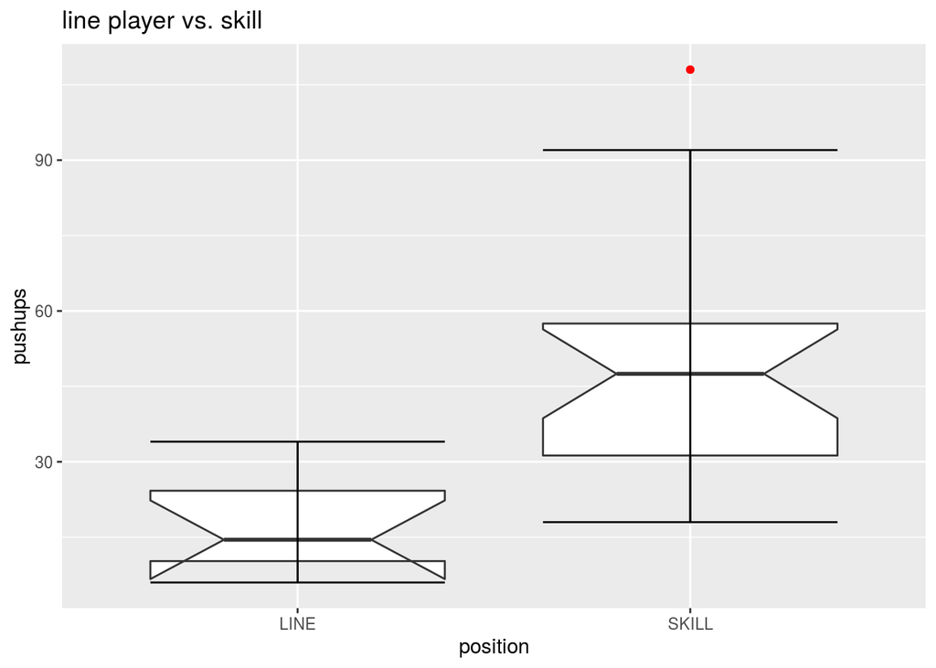

```r
basicCN + geom_boxplot(notch=TRUE,outlier.color = "red") + stat_boxplot(geom ='errorbar') + labs(title="line player vs. skill")
```

### Numerical Descriptive Results

```r
favstats(pushups~position,data=mydata)
```

```
##   position min    Q1 median    Q3 max     mean        sd  n missing
## 1     LINE   6 10.25   14.5 24.25  34 17.12500  9.745878  8       0
## 2    SKILL  18 31.25   47.5 57.50 108 49.72727 23.036579 22       0
```

This graph shows that the mean-value of pushups for line players is 17.2 and the skill players mean-value was about 50. In two minutes, skill players on average were able to do almost three times more push ups than the line players.

## Inferential Results

```r
t.test(pushups~position,data=mydata)
```

```
##
##  Welch Two Sample t-test
##
## data:  pushups by position
## t = -5.4341, df = 27.079, p-value = 9.421e-06
## alternative hypothesis: true difference in means is not equal to 0
## 95 percent confidence interval:
##  -44.91068 -20.29387
## sample estimates:
##  mean in group LINE mean in group SKILL
##            17.12500            49.72727
```

The p-value is 0.000009421.The p-value is a such a small number that this result is unlikely to occur by chance.

# Discussion and Conclusion

The original question was what players on the football team did more pushups:line players or skill players. Using evidence gathered from the boxplots and the numerical results, it is clear that the skill players average number of pushups in 2 minutes was almost three times greater than the line players. 50:17 skill players to line players. We conclude that the skill players can do more pushups than the line players by acknowledging how tiny the p-value is.